# Solar Energy Production

In this notebook we will analyse the solar energy production data.

```python
import pandas as pd
import numpy as np
import matplotlib.pyplot as plt
import seaborn as sns

pd.set_option('display.max_columns', None)

print('Pandas version:', pd.__version__) # 2.2.3
print('Numpy version:', np.__version__) # 1.26.4
print('Seaborn version:', sns.__version__) # 0.13.2
```

```
Pandas version: 2.2.3
Numpy version: 1.26.4
Seaborn version: 0.13.2
```

## Load the dataset

We will start with loading the dataset for energy production. We will load the entire production dataset and then filter it to get the data we will need in this notebook. The dataset was downloaded from [ned](https://ned.nl) and we are using the cleaned dataset in this notebook.

```python
df = pd.read_csv('../data/ProductionData/cleaned_energie_opwek.csv')
df = df[df['type'] == 'Solar'].reset_index(drop=True)
df
```

|  | datetime | point | type | granularity | timezone | activity | classification | capacity | volume | percentage | emission | emissionfactor |
| --- | --- | --- | --- | --- | --- | --- | --- | --- | --- | --- | --- | --- |
| 0 | 2020-12-31 23:00:00 | Nederland | Solar | Hour | UTC | Providing | Current | 0 | 0 | 0.0 | 0 | 0.0 |
| 1 | 2021-01-01 00:00:00 | Nederland | Solar | Hour | UTC | Providing | Current | 0 | 0 | 0.0 | 0 | 0.0 |
| 2 | 2021-01-01 01:00:00 | Nederland | Solar | Hour | UTC | Providing | Current | 0 | 0 | 0.0 | 0 | 0.0 |
| 3 | 2021-01-01 02:00:00 | Nederland | Solar | Hour | UTC | Providing | Current | 0 | 0 | 0.0 | 0 | 0.0 |
| 4 | 2021-01-01 03:00:00 | Nederland | Solar | Hour | UTC | Providing | Current | 0 | 0 | 0.0 | 0 | 0.0 |
| ... | ... | ... | ... | ... | ... | ... | ... | ... | ... | ... | ... | ... |
| 26275 | 2023-12-31 18:00:00 | Nederland | Solar | Hour | UTC | Providing | Current | 0 | 0 | 0.0 | 0 | 0.0 |
| 26276 | 2023-12-31 19:00:00 | Nederland | Solar | Hour | UTC | Providing | Current | 0 | 0 | 0.0 | 0 | 0.0 |
| 26277 | 2023-12-31 20:00:00 | Nederland | Solar | Hour | UTC | Providing | Current | 0 | 0 | 0.0 | 0 | 0.0 |
| 26278 | 2023-12-31 21:00:00 | Nederland | Solar | Hour | UTC | Providing | Current | 0 | 0 | 0.0 | 0 | 0.0 |
| 26279 | 2023-12-31 22:00:00 | Nederland | Solar | Hour | UTC | Providing | Current | 0 | 0 | 0.0 | 0 | 0.0 |

26280 rows × 12 columns

## Data Analysis

```python
df.info()
```

```
<class 'pandas.core.frame.DataFrame'>
RangeIndex: 26280 entries, 0 to 26279
Data columns (total 12 columns):
 #   Column          Non-Null Count  Dtype
---  ------          --------------  -----
 0   datetime        26280 non-null  object
 1   point           26280 non-null  object
 2   type            26280 non-null  object
 3   granularity     26280 non-null  object
 4   timezone        26280 non-null  object
 5   activity        26280 non-null  object
 6   classification  26280 non-null  object
 7   capacity        26280 non-null  int64
 8   volume          26280 non-null  int64
 9   percentage      26280 non-null  float64
 10  emission        26280 non-null  int64
 11  emissionfactor  26280 non-null  float64
dtypes: float64(2), int64(3), object(7)
memory usage: 2.4+ MB
```

We can see the `datetime` column is an object type, so we will change it to a datetime type. We will also split the date and time columns, so they are separate.

```python
df['date'] = pd.to_datetime(df['datetime']).dt.date
df['time'] = pd.to_datetime(df['datetime']).dt.time

df = df.drop(columns=['datetime'])

df = df[['date', 'time'] + [col for col in df.columns if col not in ['date', 'time']]]

df.head()
```

|  | date | time | point | type | granularity | timezone | activity | classification | capacity | volume | percentage | emission | emissionfactor |
| --- | --- | --- | --- | --- | --- | --- | --- | --- | --- | --- | --- | --- | --- |
| 0 | 2020-12-31 | 23:00:00 | Nederland | Solar | Hour | UTC | Providing | Current | 0 | 0 | 0.0 | 0 | 0.0 |
| 1 | 2021-01-01 | 00:00:00 | Nederland | Solar | Hour | UTC | Providing | Current | 0 | 0 | 0.0 | 0 | 0.0 |
| 2 | 2021-01-01 | 01:00:00 | Nederland | Solar | Hour | UTC | Providing | Current | 0 | 0 | 0.0 | 0 | 0.0 |
| 3 | 2021-01-01 | 02:00:00 | Nederland | Solar | Hour | UTC | Providing | Current | 0 | 0 | 0.0 | 0 | 0.0 |
| 4 | 2021-01-01 | 03:00:00 | Nederland | Solar | Hour | UTC | Providing | Current | 0 | 0 | 0.0 | 0 | 0.0 |

```python
df['date'] = pd.to_datetime(df['date'])
```

By loading the dataframe we can see the very first row contains data from the year 2020. Since we are only focussing on 2021-2023 we don't need this row and we will drop it.

```python
df = df[(df['date'].dt.year >= 2021) & (df['date'].dt.year <= 2023)]
df.head()
```

|  | date | time | point | type | granularity | timezone | activity | classification | capacity | volume | percentage | emission | emissionfactor |
| --- | --- | --- | --- | --- | --- | --- | --- | --- | --- | --- | --- | --- | --- |
| 1 | 2021-01-01 | 00:00:00 | Nederland | Solar | Hour | UTC | Providing | Current | 0 | 0 | 0.0 | 0 | 0.0 |
| 2 | 2021-01-01 | 01:00:00 | Nederland | Solar | Hour | UTC | Providing | Current | 0 | 0 | 0.0 | 0 | 0.0 |
| 3 | 2021-01-01 | 02:00:00 | Nederland | Solar | Hour | UTC | Providing | Current | 0 | 0 | 0.0 | 0 | 0.0 |
| 4 | 2021-01-01 | 03:00:00 | Nederland | Solar | Hour | UTC | Providing | Current | 0 | 0 | 0.0 | 0 | 0.0 |
| 5 | 2021-01-01 | 04:00:00 | Nederland | Solar | Hour | UTC | Providing | Current | 0 | 0 | 0.0 | 0 | 0.0 |

```python
df.isnull().sum()
```

```
date              0
time              0
point             0
type              0
granularity       0
timezone          0
activity          0
classification    0
capacity          0
volume            0
percentage        0
emission          0
emissionfactor    0
dtype: int64
```

We can see the dataset does not contain any null values.

For our analysis we don't need all the colums, so we will start with dropping the unnecessary columns. The columns we will focus on are the `date`, `time`, `capacity`, `volume`, `percentage`, `emission` and `emissionfactor`.

```python
cols_to_drop = ['point', 'type', 'granularity', 'timezone', 'activity', 'classification']

df_production = df.drop(columns=cols_to_drop)
df_production.head()
```

|  | date | time | capacity | volume | percentage | emission | emissionfactor |
| --- | --- | --- | --- | --- | --- | --- | --- |
| 1 | 2021-01-01 | 00:00:00 | 0 | 0 | 0.0 | 0 | 0.0 |
| 2 | 2021-01-01 | 01:00:00 | 0 | 0 | 0.0 | 0 | 0.0 |
| 3 | 2021-01-01 | 02:00:00 | 0 | 0 | 0.0 | 0 | 0.0 |
| 4 | 2021-01-01 | 03:00:00 | 0 | 0 | 0.0 | 0 | 0.0 |
| 5 | 2021-01-01 | 04:00:00 | 0 | 0 | 0.0 | 0 | 0.0 |

We will start with aggregating the data for analysis, we will use the sum of the `capacity`, `volume` and `emission` and take the average of the `percentage` and `emissionfactor`.

```python
df_production_daily = df.groupby('date', as_index=False).agg({
    'capacity': 'sum',
    'volume': 'sum',
    'percentage': 'mean',
    'emission': 'sum',
    'emissionfactor': 'mean'
})

df_production_daily.head()
```

|  | date | capacity | volume | percentage | emission | emissionfactor |
| --- | --- | --- | --- | --- | --- | --- |
| 0 | 2021-01-01 | 7969775 | 7969775 | 0.035783 | 0 | 0.0 |
| 1 | 2021-01-02 | 5772534 | 5772534 | 0.025894 | 0 | 0.0 |
| 2 | 2021-01-03 | 4362255 | 4362255 | 0.019550 | 0 | 0.0 |
| 3 | 2021-01-04 | 3171814 | 3171814 | 0.014202 | 0 | 0.0 |
| 4 | 2021-01-05 | 2622513 | 2622513 | 0.011732 | 0 | 0.0 |

```python
difference = df[df['capacity'] != df['volume']]
difference
```

|  | date | time | point | type | granularity | timezone | activity | classification | capacity | volume | percentage | emission | emissionfactor |
| --- | --- | --- | --- | --- | --- | --- | --- | --- | --- | --- | --- | --- | --- |

We can see the `capacity` and `volume` are the exact same for the entire dataframe.

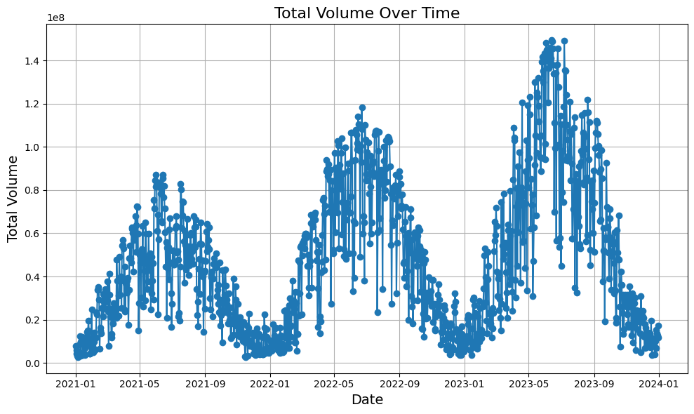

```python
plt.figure(figsize=(10, 6))
plt.plot(df_production_daily['date'], df_production_daily['volume'], marker='o', linestyle='-')

plt.title('Total Volume Over Time', fontsize=16)
plt.xlabel('Date', fontsize=14)
plt.ylabel('Total Volume', fontsize=14)
plt.grid(True)

plt.xticks()
plt.tight_layout()

plt.show()
```

By looking at this graph we can see that in general the energy production is higher in the summer months. However this graph is not very useful for details, as there are too many data points in it. However, we can see the production of solar energy has increased over the years.

That's why we will look at the volume per month, and make a new graph so we can get a better overview.

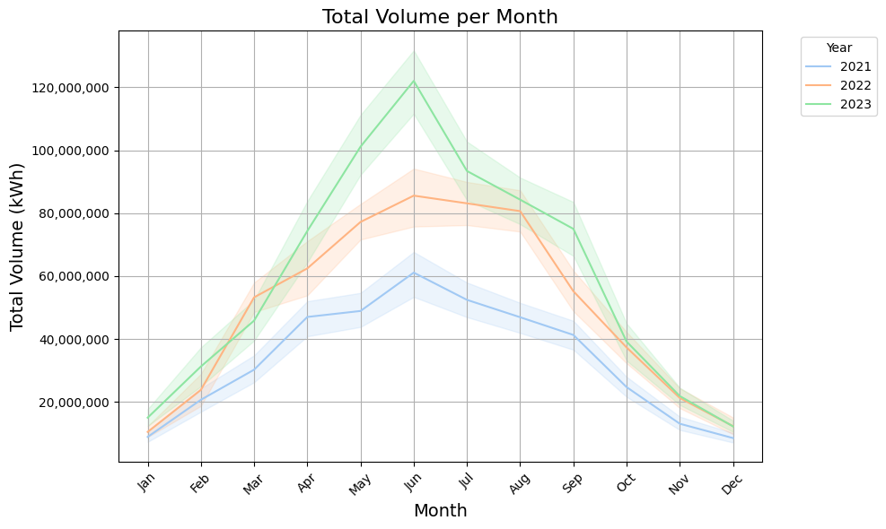

```python
from matplotlib.ticker import FuncFormatter

df_production_daily['Year'] = df_production_daily['date'].dt.year
df_production_daily['Month'] = df_production_daily['date'].dt.month

plt.figure(figsize=(10, 6))
sns.lineplot(x=df_production_daily['Month'], y=df_production_daily['volume'], hue=df_production_daily['Year'], palette='pastel')

plt.title('Total Volume per Month', fontsize=16)
plt.xlabel('Month', fontsize=14)
plt.ylabel('Total Volume (kWh)', fontsize=14)
plt.xticks(ticks=range(1, 13), labels=['Jan', 'Feb', 'Mar', 'Apr', 'May', 'Jun', 'Jul', 'Aug', 'Sep', 'Oct', 'Nov', 'Dec'], rotation=45)
plt.legend(title='Year', bbox_to_anchor=(1.05, 1), loc='upper left')
plt.grid(True)

formatter = FuncFormatter(lambda x, _: f'{x:,.0f}')
plt.gca().yaxis.set_major_formatter(formatter)

plt.tight_layout()
plt.show()
```

Here we can clearly see the total energy production is higher in the summer months compared to the winter. This seems logical, however we will still compare the data to weather data to see the total amount of sun hours. We can also see there are some fluctuations in the data and that it is not a smooth line. This is because the data is aggregated from hourly data to daily data, and it is most likely influenced by the weather and the total amount of sun hours.

What is also interesting to see is that the total energy production appears to be overall higher in 2023, this could be because the amount of solar panels in the Netherlands has grown. We will look at this at a later point.

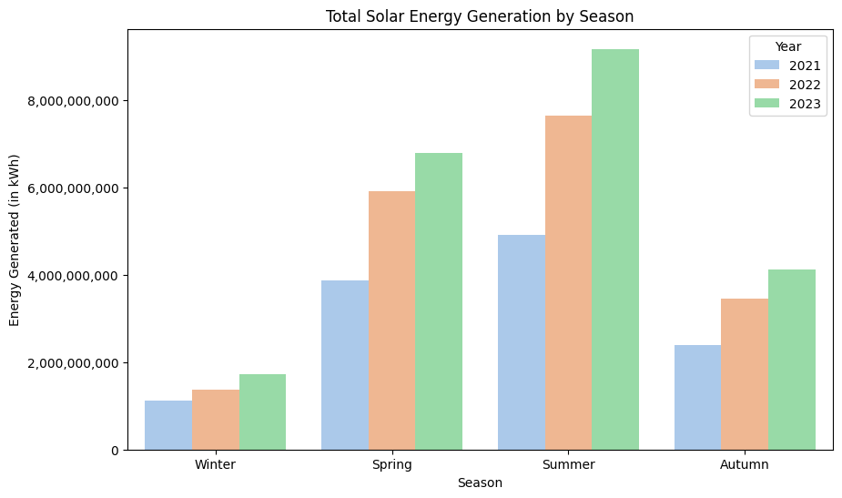

```python
df_season = df.copy()
df_season['Month'] = df['date'].dt.month
df_season['Year'] = df['date'].dt.year

monthly_data = df_season.groupby(['Year', 'Month'])['volume'].sum().reset_index()

season_map = {12: 'Winter', 1: 'Winter', 2: 'Winter',
              3: 'Spring', 4: 'Spring', 5: 'Spring',
              6: 'Summer', 7: 'Summer', 8: 'Summer',
              9: 'Autumn', 10: 'Autumn', 11: 'Autumn'}

season_order = ['Winter', 'Spring', 'Summer', 'Autumn']

df_season['Season'] = df_season['Month'].map(season_map)

seasonal_data = df_season.groupby(['Year', 'Season'])['volume'].sum().reset_index()

plt.figure(figsize=(10, 6))
sns.barplot(x='Season', y='volume', hue='Year', data=seasonal_data, palette='pastel', order=season_order)
plt.title('Total Solar Energy Generation by Season')
plt.ylabel('Energy Generated (in kWh)')

plt.gca().yaxis.set_major_formatter(formatter)

plt.show()
```

This bar chart confirms that the solar energy production is higher in the summer months. What is interesting is that the difference between the years in the winter is not that big compared to the summer.

### Weather Data

We will load the weather dataset to see if there is a significant correlation between the weather data and the solar energy production.

```python
df_weather = pd.read_csv('../data/Weather/WeatherDataCleaned.csv')
df_weather
```

|  | Datetime | Station | WindDirection | WindSpeedAvg60min | WindSpeedAvg10min | WindGust | Temperature | DewPoint | Sunshineperhour | GlobalRadiation | PrecipitationDuration | HourlyPrecipitationAmount | Pressure | HorizontalVisibility | CloudCover | RelativeAtmosphericHumidity | IndicatorWeatherCode | Fog | Rain | Snow | Thunder | IceFormation | AvgDailyTemperature | TemperatureAvgMonthlyTemperature |
| --- | --- | --- | --- | --- | --- | --- | --- | --- | --- | --- | --- | --- | --- | --- | --- | --- | --- | --- | --- | --- | --- | --- | --- | --- |
| 0 | 2017-01-01 00:00:00 | 260 | 200 | 40 | 40 | 60 | 1.2 | 12 | 0 | 0 | 0 | -1 | 10234 | 5 | 9 | 99 | 7 | 1 | 1 | 0 | 0 | 0 | 0.520833 | 1.565591 |
| 1 | 2017-01-01 01:00:00 | 260 | 200 | 40 | 40 | 70 | 1.2 | 12 | 0 | 0 | 0 | 0 | 10226 | 3 | 9 | 99 | 7 | 1 | 0 | 0 | 0 | 0 | 0.520833 | 1.565591 |
| 2 | 2017-01-01 02:00:00 | 260 | 210 | 40 | 40 | 70 | 1.3 | 12 | 0 | 0 | 0 | 0 | 10218 | 9 | 9 | 99 | 7 | 1 | 0 | 0 | 0 | 0 | 0.520833 | 1.565591 |
| 3 | 2017-01-01 03:00:00 | 260 | 210 | 40 | 40 | 70 | 1.4 | 13 | 0 | 0 | 0 | 0 | 10210 | 11 | 8 | 98 | 7 | 1 | 0 | 0 | 0 | 0 | 0.520833 | 1.565591 |
| 4 | 2017-01-01 04:00:00 | 260 | 210 | 40 | 30 | 70 | 1.5 | 14 | 0 | 0 | 0 | 0 | 10202 | 18 | 8 | 98 | 7 | 0 | 0 | 0 | 0 | 0 | 0.520833 | 1.565591 |
| ... | ... | ... | ... | ... | ... | ... | ... | ... | ... | ... | ... | ... | ... | ... | ... | ... | ... | ... | ... | ... | ... | ... | ... | ... |
| 70123 | 2024-12-31 19:00:00 | 260 | 210 | 70 | 80 | 140 | 6.2 | 37 | 0 | 0 | 0 | 0 | 10182 | 76 | 8 | 84 | 5 | 0 | 0 | 0 | 0 | 0 | 4.625000 | 6.067339 |
| 70124 | 2024-12-31 20:00:00 | 260 | 210 | 80 | 70 | 160 | 6.8 | 41 | 0 | 0 | 0 | 0 | 10182 | 81 | 8 | 82 | 5 | 0 | 0 | 0 | 0 | 0 | 4.625000 | 6.067339 |
| 70125 | 2024-12-31 21:00:00 | 260 | 210 | 80 | 80 | 140 | 6.8 | 42 | 0 | 0 | 0 | 0 | 10173 | 78 | 8 | 83 | 5 | 0 | 0 | 0 | 0 | 0 | 4.625000 | 6.067339 |
| 70126 | 2024-12-31 22:00:00 | 260 | 210 | 80 | 90 | 130 | 7.4 | 48 | 0 | 0 | 0 | 0 | 10169 | 70 | 8 | 83 | 5 | 0 | 0 | 0 | 0 | 0 | 4.625000 | 6.067339 |
| 70127 | 2024-12-31 23:00:00 | 260 | 210 | 80 | 80 | 160 | 8.0 | 53 | 0 | 0 | 0 | 0 | 10157 | 59 | 8 | 83 | 7 | 0 | 0 | 0 | 0 | 0 | 4.625000 | 6.067339 |

70128 rows × 24 columns

The weather data starts in 2017 and ends in 2024. For now we will only look at 2021 till 2023, since the solar energy production is not yet ready and we only have these years available right now. For this reason we will first filter the dataset so it contains only data from 2021 to 2023. For this we will also split the datetime column into two separate columns.

```python
df_weather['Date'] = pd.to_datetime(df_weather['Datetime']).dt.date
df_weather['Time'] = pd.to_datetime(df_weather['Datetime']).dt.time

df_weather = df_weather.drop(columns=['Datetime'])

df_weather = df_weather[['Date', 'Time'] + [col for col in df_weather.columns if col not in ['Date', 'Time']]]

df_weather.head()
```

|  | Date | Time | Station | WindDirection | WindSpeedAvg60min | WindSpeedAvg10min | WindGust | Temperature | DewPoint | Sunshineperhour | GlobalRadiation | PrecipitationDuration | HourlyPrecipitationAmount | Pressure | HorizontalVisibility | CloudCover | RelativeAtmosphericHumidity | IndicatorWeatherCode | Fog | Rain | Snow | Thunder | IceFormation | AvgDailyTemperature | TemperatureAvgMonthlyTemperature |
| --- | --- | --- | --- | --- | --- | --- | --- | --- | --- | --- | --- | --- | --- | --- | --- | --- | --- | --- | --- | --- | --- | --- | --- | --- | --- |
| 0 | 2017-01-01 | 00:00:00 | 260 | 200 | 40 | 40 | 60 | 1.2 | 12 | 0 | 0 | 0 | -1 | 10234 | 5 | 9 | 99 | 7 | 1 | 1 | 0 | 0 | 0 | 0.520833 | 1.565591 |
| 1 | 2017-01-01 | 01:00:00 | 260 | 200 | 40 | 40 | 70 | 1.2 | 12 | 0 | 0 | 0 | 0 | 10226 | 3 | 9 | 99 | 7 | 1 | 0 | 0 | 0 | 0 | 0.520833 | 1.565591 |
| 2 | 2017-01-01 | 02:00:00 | 260 | 210 | 40 | 40 | 70 | 1.3 | 12 | 0 | 0 | 0 | 0 | 10218 | 9 | 9 | 99 | 7 | 1 | 0 | 0 | 0 | 0 | 0.520833 | 1.565591 |
| 3 | 2017-01-01 | 03:00:00 | 260 | 210 | 40 | 40 | 70 | 1.4 | 13 | 0 | 0 | 0 | 0 | 10210 | 11 | 8 | 98 | 7 | 1 | 0 | 0 | 0 | 0 | 0.520833 | 1.565591 |
| 4 | 2017-01-01 | 04:00:00 | 260 | 210 | 40 | 30 | 70 | 1.5 | 14 | 0 | 0 | 0 | 0 | 10202 | 18 | 8 | 98 | 7 | 0 | 0 | 0 | 0 | 0 | 0.520833 | 1.565591 |

```python
df_weather['Date'] = pd.to_datetime(df_weather['Date'])
df_weather = df_weather[(df_weather['Date'].dt.year >= 2021) & (df_weather['Date'].dt.year <= 2023)]
df_weather = df_weather.reset_index(drop=True)
df_weather
```

|  | Date | Time | Station | WindDirection | WindSpeedAvg60min | WindSpeedAvg10min | WindGust | Temperature | DewPoint | Sunshineperhour | GlobalRadiation | PrecipitationDuration | HourlyPrecipitationAmount | Pressure | HorizontalVisibility | CloudCover | RelativeAtmosphericHumidity | IndicatorWeatherCode | Fog | Rain | Snow | Thunder | IceFormation | AvgDailyTemperature | TemperatureAvgMonthlyTemperature |
| --- | --- | --- | --- | --- | --- | --- | --- | --- | --- | --- | --- | --- | --- | --- | --- | --- | --- | --- | --- | --- | --- | --- | --- | --- | --- |
| 0 | 2021-01-01 | 00:00:00 | 260 | 230 | 10 | 10 | 20 | -2.5 | -26 | 0 | 0 | 0 | 0 | 10059 | 1 | 0 | 98 | 7 | 1 | 0 | 0 | 0 | 1 | 2.970833 | 3.376747 |
| 1 | 2021-01-01 | 01:00:00 | 260 | 230 | 10 | 10 | 20 | -3.2 | -34 | 0 | 0 | 0 | 0 | 10061 | 0 | 1 | 98 | 7 | 1 | 0 | 0 | 0 | 1 | 2.970833 | 3.376747 |
| 2 | 2021-01-01 | 02:00:00 | 260 | 230 | 20 | 20 | 30 | -2.7 | -29 | 0 | 0 | 0 | 0 | 10064 | 4 | 7 | 98 | 7 | 1 | 0 | 0 | 0 | 1 | 2.970833 | 3.376747 |
| 3 | 2021-01-01 | 03:00:00 | 260 | 220 | 20 | 20 | 30 | -1.1 | -14 | 0 | 0 | 0 | 0 | 10064 | 15 | 8 | 98 | 7 | 1 | 0 | 0 | 0 | 1 | 2.970833 | 3.376747 |
| 4 | 2021-01-01 | 04:00:00 | 260 | 230 | 20 | 20 | 40 | 1.1 | 5 | 0 | 0 | 0 | 0 | 10064 | 18 | 8 | 95 | 7 | 0 | 0 | 0 | 0 | 0 | 2.970833 | 3.376747 |
| ... | ... | ... | ... | ... | ... | ... | ... | ... | ... | ... | ... | ... | ... | ... | ... | ... | ... | ... | ... | ... | ... | ... | ... | ... | ... |
| 26275 | 2023-12-31 | 19:00:00 | 260 | 200 | 80 | 70 | 140 | 8.6 | 50 | 0 | 0 | 0 | -1 | 9951 | 75 | 8 | 77 | 7 | 0 | 1 | 0 | 0 | 0 | 8.829167 | 6.888441 |
| 26276 | 2023-12-31 | 20:00:00 | 260 | 200 | 70 | 70 | 150 | 8.2 | 56 | 0 | 0 | 0 | -1 | 9954 | 70 | 8 | 84 | 7 | 0 | 1 | 0 | 0 | 0 | 8.829167 | 6.888441 |
| 26277 | 2023-12-31 | 21:00:00 | 260 | 200 | 70 | 70 | 140 | 8.1 | 56 | 0 | 0 | 3 | 2 | 9955 | 70 | 8 | 84 | 7 | 0 | 1 | 0 | 0 | 0 | 8.829167 | 6.888441 |
| 26278 | 2023-12-31 | 22:00:00 | 260 | 210 | 80 | 80 | 150 | 8.6 | 50 | 0 | 0 | 0 | -1 | 9959 | 75 | 8 | 78 | 7 | 0 | 1 | 0 | 0 | 0 | 8.829167 | 6.888441 |
| 26279 | 2023-12-31 | 23:00:00 | 260 | 210 | 80 | 80 | 150 | 8.2 | 44 | 0 | 0 | 0 | -1 | 9962 | 67 | 8 | 77 | 7 | 0 | 1 | 0 | 0 | 0 | 8.829167 | 6.888441 |

26280 rows × 25 columns

In this notebook we will only look at the solar energy production, for this reason we will also only look at the weather data that is related to the solar energy production. Sunshine and the amount of sun hours are not the only factor. The temperature can be important, the cloud coverage is important and even wind could impact the solar energy production ([source](https://www.gaslicht.com/nieuws/bij-welk-weer-wekken-zonnepanelen-de-meeste-energie-op#:~:text=Hogere%20temperatuur%3A%20lagere%20opbrengst,maar%20temperaturen%20van%2030%20graden.)). We will drop the other columns for that reason.

```python
cols_to_drop = ['Pressure', 'RelativeAtmosphericHumidity', 'HourlyPrecipitationAmount', 'PrecipitationDuration', 'Rain', 'Snow', 'Fog', 'Thunder', 'IceFormation', 'TemperatureAvgMonthlyTemperature', 'IndicatorWeatherCode', 'DewPoint', 'WindSpeedAvg10min', 'Station']

df_weather = df_weather.drop(columns=cols_to_drop)
df_weather.head()
```

|  | Date | Time | WindDirection | WindSpeedAvg60min | WindGust | Temperature | Sunshineperhour | GlobalRadiation | HorizontalVisibility | CloudCover | AvgDailyTemperature |
| --- | --- | --- | --- | --- | --- | --- | --- | --- | --- | --- | --- |
| 0 | 2021-01-01 | 00:00:00 | 230 | 10 | 20 | -2.5 | 0 | 0 | 1 | 0 | 2.970833 |
| 1 | 2021-01-01 | 01:00:00 | 230 | 10 | 20 | -3.2 | 0 | 0 | 0 | 1 | 2.970833 |
| 2 | 2021-01-01 | 02:00:00 | 230 | 20 | 30 | -2.7 | 0 | 0 | 4 | 7 | 2.970833 |
| 3 | 2021-01-01 | 03:00:00 | 220 | 20 | 30 | -1.1 | 0 | 0 | 15 | 8 | 2.970833 |
| 4 | 2021-01-01 | 04:00:00 | 230 | 20 | 40 | 1.1 | 0 | 0 | 18 | 8 | 2.970833 |

```python
df_weather.info()
```

```
<class 'pandas.core.frame.DataFrame'>
RangeIndex: 26280 entries, 0 to 26279
Data columns (total 11 columns):
 #   Column                Non-Null Count  Dtype
---  ------                --------------  -----
 0   Date                  26280 non-null  datetime64[ns]
 1   Time                  26280 non-null  object
 2   WindDirection         26280 non-null  int64
 3   WindSpeedAvg60min     26280 non-null  int64
 4   WindGust              26280 non-null  int64
 5   Temperature           26280 non-null  float64
 6   Sunshineperhour       26280 non-null  int64
 7   GlobalRadiation       26280 non-null  int64
 8   HorizontalVisibility  26280 non-null  int64
 9   CloudCover            26280 non-null  int64
 10  AvgDailyTemperature   26280 non-null  float64
dtypes: datetime64[ns](1), float64(2), int64(7), object(1)
memory usage: 2.2+ MB
```

```python
df_weather.isnull().sum()
```

```
Date                    0
Time                    0
WindDirection           0
WindSpeedAvg60min       0
WindGust                0
Temperature             0
Sunshineperhour         0
GlobalRadiation         0
HorizontalVisibility    0
CloudCover              0
AvgDailyTemperature     0
dtype: int64
```

There appear to be no NaN values in the dataset.

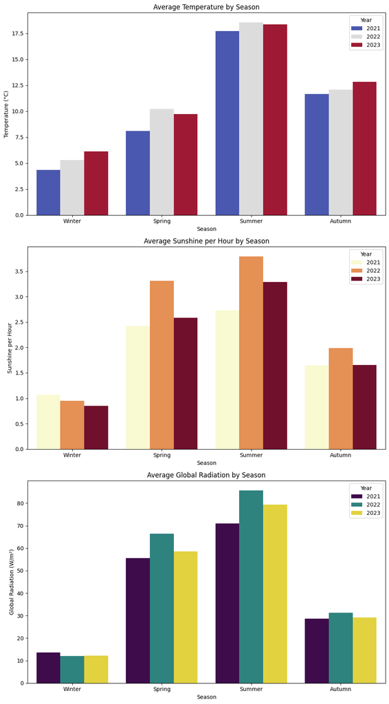

```python
df_weather_season = df_weather.copy()
df_weather_season['Month'] = df_weather_season['Date'].dt.month
df_weather_season['Year'] = df_weather_season['Date'].dt.year

season_map = {12: 'Winter', 1: 'Winter', 2: 'Winter',
              3: 'Spring', 4: 'Spring', 5: 'Spring',
              6: 'Summer', 7: 'Summer', 8: 'Summer',
              9: 'Autumn', 10: 'Autumn', 11: 'Autumn'}

season_order = ['Winter', 'Spring', 'Summer', 'Autumn']

df_weather_season['Season'] = df_weather_season['Month'].map(season_map)

seasonal_weather_data = df_weather_season.groupby(['Year', 'Season'])[['Temperature', 'Sunshineperhour', 'GlobalRadiation']].mean().reset_index()

fig, axes = plt.subplots(3, 1, figsize=(10, 18))

sns.barplot(x='Season', y='Temperature', hue='Year', data=seasonal_weather_data, palette='coolwarm', ax=axes[0], order=season_order)
axes[0].set_title('Average Temperature by Season')
axes[0].set_ylabel('Temperature (°C)')

sns.barplot(x='Season', y='Sunshineperhour', hue='Year', data=seasonal_weather_data, palette='YlOrRd', ax=axes[1], order=season_order)
axes[1].set_title('Average Sunshine per Hour by Season')
axes[1].set_ylabel('Sunshine per Hour')

sns.barplot(x='Season', y='GlobalRadiation', hue='Year', data=seasonal_weather_data, palette='viridis', ax=axes[2], order=season_order)
axes[2].set_title('Average Global Radiation by Season')
axes[2].set_ylabel('Global Radiation (W/m²)')

for ax in axes:
    handles, labels = ax.get_legend_handles_labels()
    labels = [str(round(float(label))) for label in labels]
    ax.legend(handles, labels, title="Year")

plt.tight_layout()
plt.show()
```

These bar charts are not very surprising, they show that the temperature and average sunshine per hour are higher in summer compared to the colder months. What is interesting is that the average sunshine per hour and the average global radiation were both higher in 2022, compared to the other years. We can see the average sunshine per hour and average global radiation in the winter are both very close to each other, being slightly higher in 2021. This could explain why the difference in solar energy production in the winter months is not that big.

#### Correlation between solar production and weather

Next we will look at the correlation between the weather and the total energy production. For this we will combine both datasets.

```python
df_production.rename(columns={'date': 'Date'}, inplace=True)
df_production.rename(columns={'time': 'Time'}, inplace=True)

df_weather['Date'] = pd.to_datetime(df_production['Date'])

df_production_weather = pd.merge(df_weather, df_production, how='inner', on=['Date', 'Time'])
df_production_weather.head()
```

|  | Date | Time | WindDirection | WindSpeedAvg60min | WindGust | Temperature | Sunshineperhour | GlobalRadiation | HorizontalVisibility | CloudCover | AvgDailyTemperature | capacity | volume | percentage | emission | emissionfactor |
| --- | --- | --- | --- | --- | --- | --- | --- | --- | --- | --- | --- | --- | --- | --- | --- | --- |
| 0 | 2021-01-01 | 01:00:00 | 230 | 10 | 20 | -3.2 | 0 | 0 | 0 | 1 | 2.970833 | 0 | 0 | 0.0 | 0 | 0.0 |
| 1 | 2021-01-01 | 02:00:00 | 230 | 20 | 30 | -2.7 | 0 | 0 | 4 | 7 | 2.970833 | 0 | 0 | 0.0 | 0 | 0.0 |
| 2 | 2021-01-01 | 03:00:00 | 220 | 20 | 30 | -1.1 | 0 | 0 | 15 | 8 | 2.970833 | 0 | 0 | 0.0 | 0 | 0.0 |
| 3 | 2021-01-01 | 04:00:00 | 230 | 20 | 40 | 1.1 | 0 | 0 | 18 | 8 | 2.970833 | 0 | 0 | 0.0 | 0 | 0.0 |
| 4 | 2021-01-01 | 05:00:00 | 230 | 30 | 40 | 1.9 | 0 | 0 | 44 | 8 | 2.970833 | 0 | 0 | 0.0 | 0 | 0.0 |

We will also export this combined dataset, so we can use it for making a model.

```python
file_path = '../data/Model/solar_production_weather.csv'
df_production_weather.to_csv(file_path, index=False)
```

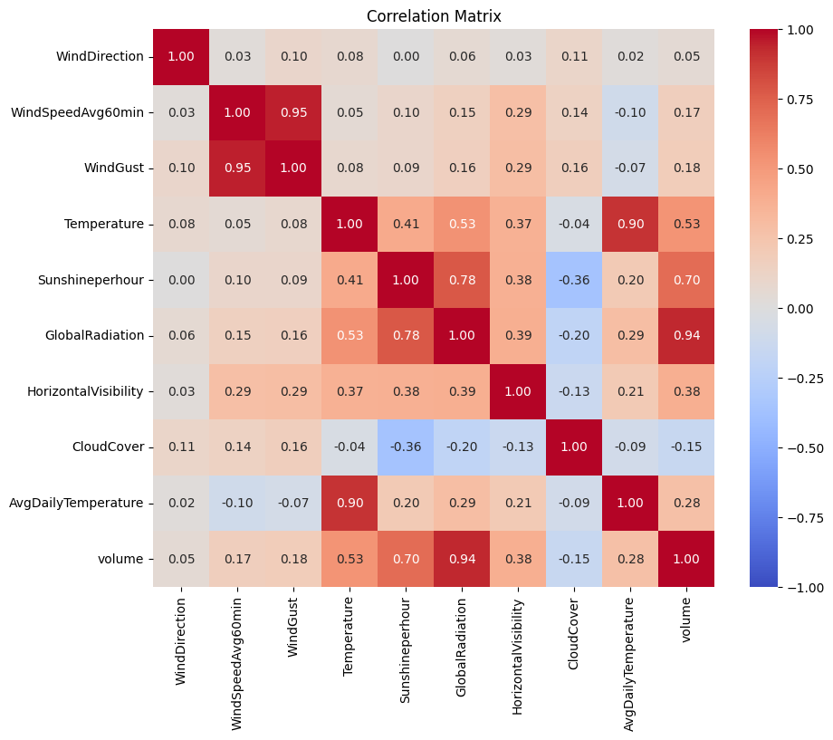

```python
df_corr = df_production_weather[['WindDirection', 'WindSpeedAvg60min', 'WindGust', 'Temperature',
                                     'Sunshineperhour', 'GlobalRadiation', 'HorizontalVisibility',
                                     'CloudCover', 'AvgDailyTemperature', 'volume']]

correlation_matrix = df_corr.corr()

plt.figure(figsize=(10, 8))
sns.heatmap(correlation_matrix, annot=True, cmap='coolwarm', vmin=-1, vmax=1, fmt='.2f', cbar=True)

plt.title('Correlation Matrix')
plt.show()
```

The correlation between the global radiation, sunshine per hour and temperature compared to volume seem the highest. There is not really a correlation at all between the solar energy production and the wind direction.

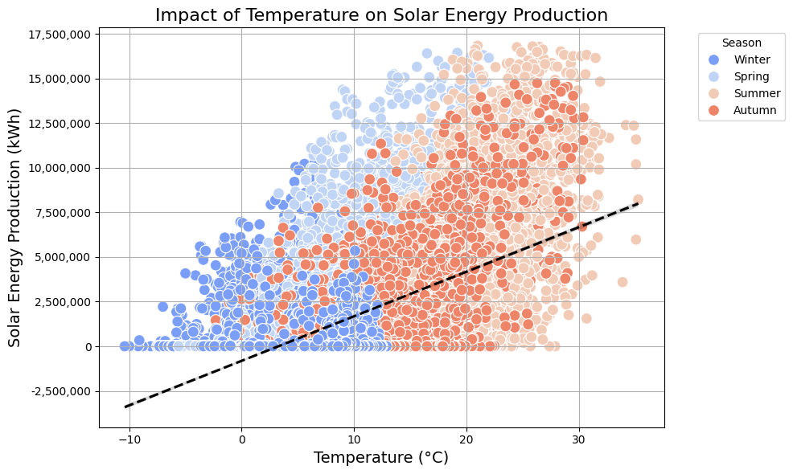

```python
season_map = {12: 'Winter', 1: 'Winter', 2: 'Winter',
              3: 'Spring', 4: 'Spring', 5: 'Spring',
              6: 'Summer', 7: 'Summer', 8: 'Summer',
              9: 'Autumn', 10: 'Autumn', 11: 'Autumn'}

df_production_weather['Month'] = df_production_weather['Date'].dt.month

df_production_weather['Season'] = df_production_weather['Month'].map(season_map)

plt.figure(figsize=(10, 6))
sns.scatterplot(x='Temperature', y='volume', data=df_production_weather, hue='Season', palette='coolwarm', s=100)

sns.regplot(x='Temperature', y='volume', data=df_production_weather, scatter=False, color='black', line_kws={'linestyle': '--'})

plt.title('Impact of Temperature on Solar Energy Production', fontsize=16)
plt.xlabel('Temperature (°C)', fontsize=14)
plt.ylabel('Solar Energy Production (kWh)', fontsize=14)
plt.legend(title='Season', bbox_to_anchor=(1.05, 1), loc='upper left')
plt.grid(True)

formatter = FuncFormatter(lambda x, _: f'{x:,.0f}')
plt.gca().yaxis.set_major_formatter(formatter)

plt.tight_layout()
plt.show()
```

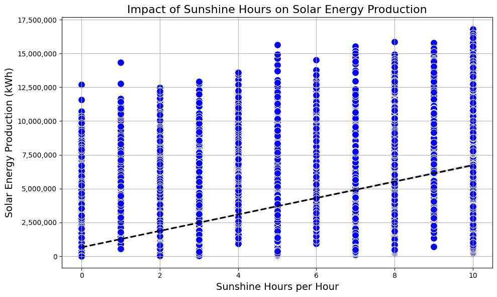

```python
plt.figure(figsize=(10, 6))

sns.scatterplot(x='Sunshineperhour', y='volume', data=df_production_weather, color='blue', s=100)

sns.regplot(x='Sunshineperhour', y='volume', data=df_production_weather, scatter=False, color='black', line_kws={'linestyle': '--'})

plt.title('Impact of Sunshine Hours on Solar Energy Production', fontsize=16)
plt.xlabel('Sunshine Hours per Hour', fontsize=14)
plt.ylabel('Solar Energy Production (kWh)', fontsize=14)
plt.grid(True)

formatter = FuncFormatter(lambda x, _: f'{x:,.0f}')
plt.gca().yaxis.set_major_formatter(formatter)

plt.tight_layout()
plt.show()
```

### Solar Panels

Next we will load the dataset that contains the amount of solar panels in the Netherlands.

```python
df_solar = pd.read_csv('../data/Other/cleaned_solar_panel_data.csv')
df_solar
```

|  | Year | Regio's | Installaties | Opgesteld vermogen omvormers | Opgesteld vermogen van zonnepanelen | Productie van zonnestroom |
| --- | --- | --- | --- | --- | --- | --- |
| 0 | 2021 | 's-Gravenhage (gemeente) | 17989.0 | NaN | 77435.0 | NaN |
| 1 | 2021 | 's-Hertogenbosch | 13883.0 | NaN | 103745.0 | NaN |
| 2 | 2021 | Aa en Hunze | 4392.0 | NaN | 33382.0 | NaN |
| 3 | 2021 | Aalsmeer | 3093.0 | NaN | 34473.0 | NaN |
| 4 | 2021 | Aalten | 3346.0 | NaN | 33100.0 | NaN |
| ... | ... | ... | ... | ... | ... | ... |
| 1456 | 2024 | Zundert | 4548.0 | 39621.0 | 45963.0 | NaN |
| 1457 | 2024 | Zutphen | 8238.0 | 55888.0 | 62270.0 | NaN |
| 1458 | 2024 | Zwartewaterland | 4620.0 | 37664.0 | 41483.0 | NaN |
| 1459 | 2024 | Zwijndrecht | 6638.0 | 100421.0 | 105131.0 | NaN |
| 1460 | 2024 | Zwolle | 25337.0 | 177869.0 | 203609.0 | NaN |

1461 rows × 6 columns

We can see the dataset also contains data from 2024, but since this year is not complete yet the data might not be as accurate. For this reason we will drop the rows where the year is 2024.

```python
df_solar = df_solar[df_solar['Year'] != 2024]
df_solar.tail()
```

|  | Year | Regio's | Installaties | Opgesteld vermogen omvormers | Opgesteld vermogen van zonnepanelen | Productie van zonnestroom |
| --- | --- | --- | --- | --- | --- | --- |
| 1094 | 2023 | Zundert | 4361.0 | 37086.0 | 42529.0 | NaN |
| 1095 | 2023 | Zutphen | 7775.0 | 53811.0 | 59915.0 | NaN |
| 1096 | 2023 | Zwartewaterland | 4022.0 | 35715.0 | 39306.0 | NaN |
| 1097 | 2023 | Zwijndrecht | 6457.0 | 99150.0 | 103719.0 | NaN |
| 1098 | 2023 | Zwolle | 24016.0 | 172119.0 | 196799.0 | NaN |

```python
df_solar.info()
```

```
<class 'pandas.core.frame.DataFrame'>
Index: 1099 entries, 0 to 1098
Data columns (total 6 columns):
 #   Column                               Non-Null Count  Dtype
---  ------                               --------------  -----
 0   Year                                 1099 non-null   int64
 1   Regio's                              1099 non-null   object
 2   Installaties                         1099 non-null   float64
 3   Opgesteld vermogen omvormers         727 non-null    float64
 4   Opgesteld vermogen van zonnepanelen  1099 non-null   float64
 5   Productie van zonnestroom            60 non-null     float64
dtypes: float64(4), int64(1), object(1)
memory usage: 60.1+ KB
```

```python
df_solar.isnull().sum()
```

```
Year                                      0
Regio's                                   0
Installaties                              0
Opgesteld vermogen omvormers            372
Opgesteld vermogen van zonnepanelen       0
Productie van zonnestroom              1039
dtype: int64
```

We can see there are quite a few NaN values in this dataset, especially in the column `Productie van zonnestroom`. This column only has a few rows that actually do contain any data, but this is not the biggest problem since we are already using the solar production dataset for the production. This means we can just drop this column.

The column we are most interested in is `Installaties` as this column contains the amount of solar panels. While cleaning the dataset we already dropped the rows that contained null values, since we could not fill them in.

```python
unique_regios = df_solar["Regio's"].unique()
unique_regios
```

```
array(["'s-Gravenhage (gemeente)", "'s-Hertogenbosch", 'Aa en Hunze',
       'Aalsmeer', 'Aalten', 'Achtkarspelen', 'Alblasserdam',
       'Albrandswaard', 'Alkmaar', 'Almelo', 'Almere',
       'Alphen aan den Rijn', 'Alphen-Chaam', 'Altena', 'Ameland',
       'Amersfoort', 'Amstelveen', 'Amsterdam', 'Apeldoorn', 'Arnhem',
       'Assen', 'Asten', 'Baarle-Nassau', 'Baarn', 'Barendrecht',
       'Barneveld', 'Beek (L.)', 'Beekdaelen', 'Beemster', 'Beesel',
       'Berg en Dal', 'Bergeijk', 'Bergen (L.)', 'Bergen (NH.)',
       'Bergen op Zoom', 'Berkelland', 'Bernheze', 'Best', 'Beuningen',
       'Beverwijk', 'Bladel', 'Blaricum', 'Bloemendaal',
       'Bodegraven-Reeuwijk', 'Boekel', 'Borger-Odoorn', 'Borne',
       'Borsele', 'Boxmeer', 'Boxtel', 'Breda', 'Brielle', 'Bronckhorst',
       'Brummen', 'Brunssum', 'Bunnik', 'Bunschoten', 'Buren',
       'Capelle aan den IJssel', 'Castricum', 'Coevorden', 'Cranendonck',
       'Cuijk', 'Culemborg', 'Dalfsen', 'Dantumadiel', 'De Bilt',
       'De Fryske Marren', 'De Ronde Venen', 'De Wolden', 'Delft',
       'Den Helder', 'Deurne', 'Deventer', 'Diemen', 'Dinkelland',
       'Doesburg', 'Doetinchem', 'Dongen', 'Dordrecht', 'Drechterland',
       'Drenthe (PV)', 'Drimmelen', 'Dronten', 'Druten', 'Duiven',
       'Echt-Susteren', 'Edam-Volendam', 'Ede', 'Eemnes', 'Eemsdelta',
       'Eersel', 'Eijsden-Margraten', 'Eindhoven', 'Elburg', 'Emmen',
       'Enkhuizen', 'Enschede', 'Epe', 'Ermelo', 'Etten-Leur',
       'Flevoland (PV)', 'Fryslân (PV)', 'Geertruidenberg',
       'Gelderland (PV)', 'Geldrop-Mierlo', 'Gemeenten; niet in te delen',
       'Gemert-Bakel', 'Gennep', 'Gilze en Rijen', 'Goeree-Overflakkee',
       'Goes', 'Goirle', 'Gooise Meren', 'Gorinchem', 'Gouda', 'Grave',
       'Groningen (PV)', 'Groningen (gemeente)', 'Gulpen-Wittem',
       'Haaksbergen', 'Haarlem', 'Haarlemmermeer', 'Halderberge',
       'Hardenberg', 'Harderwijk', 'Hardinxveld-Giessendam', 'Harlingen',
       'Hattem', 'Heemskerk', 'Heemstede', 'Heerde', 'Heerenveen',
       'Heerhugowaard', 'Heerlen', 'Heeze-Leende', 'Heiloo',
       'Hellendoorn', 'Hellevoetsluis', 'Helmond', 'Hendrik-Ido-Ambacht',
       'Hengelo (O.)', 'Het Hogeland', 'Heumen', 'Heusden', 'Hillegom',
       'Hilvarenbeek', 'Hilversum', 'Hoeksche Waard', 'Hof van Twente',
       'Hollands Kroon', 'Hoogeveen', 'Hoorn', 'Horst aan de Maas',
       'Houten', 'Huizen', 'Hulst', 'IJsselstein', 'Kaag en Braassem',
       'Kampen', 'Kapelle', 'Katwijk', 'Kerkrade', 'Koggenland',
       'Krimpen aan den IJssel', 'Krimpenerwaard', 'Laarbeek', 'Landerd',
       'Landgraaf', 'Landsmeer', 'Langedijk', 'Lansingerland',
       'Laren (NH.)', 'Leeuwarden', 'Leiden', 'Leiderdorp',
```

[output cut: 34 more lines]

```
       'Valkenswaard', 'Veendam', 'Veenendaal', 'Veere', 'Veldhoven',
       'Velsen', 'Venlo', 'Venray', 'Vijfheerenlanden', 'Vlaardingen',
       'Vlieland', 'Vlissingen', 'Voerendaal', 'Voorschoten', 'Voorst',
       'Vught', 'Waadhoeke', 'Waalre', 'Waalwijk', 'Waddinxveen',
       'Wageningen', 'Wassenaar', 'Waterland', 'Weert', 'Weesp',
       'West Betuwe', 'West Maas en Waal', 'West-Nederland (LD)',
       'Westerkwartier', 'Westerveld', 'Westervoort', 'Westerwolde',
       'Westland', 'Weststellingwerf', 'Westvoorne', 'Wierden', 'Wijchen',
       'Wijdemeren', 'Wijk bij Duurstede', 'Winterswijk', 'Woensdrecht',
       'Woerden', 'Wormerland', 'Woudenberg', 'Zaanstad', 'Zaltbommel',
       'Zandvoort', 'Zeeland (PV)', 'Zeewolde', 'Zeist', 'Zevenaar',
       'Zoetermeer', 'Zoeterwoude', 'Zuid-Holland (PV)',
       'Zuid-Nederland (LD)', 'Zuidplas', 'Zundert', 'Zutphen',
       'Zwartewaterland', 'Zwijndrecht', 'Zwolle', 'Dijk en Waard',
       'Land van Cuijk', 'Maashorst', 'Voorne aan Zee'], dtype=object)
```

We can see there are quite a few unique regions in this dataset. We will look at the regions in the Netherlands, instead of the individual cities, since this makes it more clear and readable.

```python
df_regions = df_solar[df_solar["Regio's"].str.contains(r'\(PV\)', case=False) | (df_solar["Regio's"] == "Nederland")].reset_index(drop=True)
df_regions
```

|  | Year | Regio's | Installaties | Opgesteld vermogen omvormers | Opgesteld vermogen van zonnepanelen | Productie van zonnestroom |
| --- | --- | --- | --- | --- | --- | --- |
| 0 | 2021 | Drenthe (PV) | 76601.0 | NaN | 897359.0 | 692.0 |
| 1 | 2021 | Flevoland (PV) | 46201.0 | NaN | 585708.0 | 436.0 |
| 2 | 2021 | Fryslân (PV) | 92028.0 | NaN | 865297.0 | 690.0 |
| 3 | 2021 | Gelderland (PV) | 231904.0 | NaN | 1885896.0 | 1411.0 |
| 4 | 2021 | Groningen (PV) | 77736.0 | NaN | 1156477.0 | 901.0 |
| 5 | 2021 | Limburg (PV) | 145009.0 | NaN | 1176294.0 | 912.0 |
| 6 | 2021 | Nederland | 1730285.0 | NaN | 14822880.0 | 11304.0 |
| 7 | 2021 | Niet in te delen (PV) | 426.0 | NaN | 14389.0 | 12.0 |
| 8 | 2021 | Noord-Brabant (PV) | 276145.0 | NaN | 2577937.0 | 1959.0 |
| 9 | 2021 | Noord-Holland (PV) | 218003.0 | NaN | 1440930.0 | 1114.0 |
| 10 | 2021 | Overijssel (PV) | 129004.0 | NaN | 1268994.0 | 931.0 |
| 11 | 2021 | Utrecht (PV) | 132865.0 | NaN | 781852.0 | 597.0 |
| 12 | 2021 | Zeeland (PV) | 56569.0 | NaN | 543027.0 | 434.0 |
| 13 | 2021 | Zuid-Holland (PV) | 247794.0 | NaN | 1628720.0 | 1217.0 |
| 14 | 2022 | Drenthe (PV) | 93881.0 | 1223811.0 | 1373921.0 | 1072.0 |
| 15 | 2022 | Flevoland (PV) | 61319.0 | 822438.0 | 893172.0 | 654.0 |
| 16 | 2022 | Fryslân (PV) | 117815.0 | 955883.0 | 1040289.0 | 917.0 |
| 17 | 2022 | Gelderland (PV) | 304474.0 | 2242512.0 | 2492612.0 | 2157.0 |
| 18 | 2022 | Groningen (PV) | 98213.0 | 1155914.0 | 1334696.0 | 1182.0 |
| 19 | 2022 | Limburg (PV) | 180796.0 | 1318279.0 | 1485089.0 | 1289.0 |
| 20 | 2022 | Nederland | 2298859.0 | 17451365.0 | 19536096.0 | 16659.0 |
| 21 | 2022 | Niet in te delen (PV) | 509.0 | 14768.0 | 17208.0 | 16.0 |
| 22 | 2022 | Noord-Brabant (PV) | 357763.0 | 2931556.0 | 3332012.0 | 2853.0 |
| 23 | 2022 | Noord-Holland (PV) | 289282.0 | 1704341.0 | 1872015.0 | 1619.0 |
| 24 | 2022 | Overijssel (PV) | 166640.0 | 1425321.0 | 1610957.0 | 1385.0 |
| 25 | 2022 | Utrecht (PV) | 182955.0 | 940568.0 | 1047213.0 | 909.0 |
| 26 | 2022 | Zeeland (PV) | 85246.0 | 681237.0 | 775686.0 | 691.0 |
| 27 | 2022 | Zuid-Holland (PV) | 359966.0 | 2034735.0 | 2261226.0 | 1916.0 |
| 28 | 2023 | Drenthe (PV) | 116091.0 | 1446254.0 | 1641630.0 | 1322.0 |
| 29 | 2023 | Flevoland (PV) | 76533.0 | 1073819.0 | 1184493.0 | 936.0 |
| 30 | 2023 | Fryslân (PV) | 143300.0 | 1131499.0 | 1248600.0 | 1014.0 |
| 31 | 2023 | Gelderland (PV) | 381994.0 | 2760191.0 | 3125250.0 | 2480.0 |
| 32 | 2023 | Groningen (PV) | 120133.0 | 1391598.0 | 1631399.0 | 1328.0 |
| 33 | 2023 | Limburg (PV) | 222897.0 | 1620621.0 | 1864647.0 | 1494.0 |
| 34 | 2023 | Nederland | 2875487.0 | 21394768.0 | 24301725.0 | 19580.0 |
| 35 | 2023 | Niet in te delen (PV) | 520.0 | 23689.0 | 28679.0 | 25.0 |
| 36 | 2023 | Noord-Brabant (PV) | 460314.0 | 3607684.0 | 4156315.0 | 3372.0 |
| 37 | 2023 | Noord-Holland (PV) | 357848.0 | 2063534.0 | 2302293.0 | 1878.0 |
| 38 | 2023 | Overijssel (PV) | 213419.0 | 1723447.0 | 1957508.0 | 1571.0 |
| 39 | 2023 | Utrecht (PV) | 226233.0 | 1161105.0 | 1313617.0 | 1050.0 |
| 40 | 2023 | Zeeland (PV) | 99369.0 | 834200.0 | 952198.0 | 774.0 |
| 41 | 2023 | Zuid-Holland (PV) | 456836.0 | 2557127.0 | 2895095.0 | 2337.0 |

To confirm the total amount of installaties for Nederland is the same as the sum of the regions we will calculate the sum of the installaties of the regions and compare it to Nederland.

```python
pv_rows = df_regions[df_regions['Regio\'s'].str.contains(r'\(PV\)')]
nederland_row = df_regions[df_regions['Regio\'s'] == 'Nederland']

pv_yearly_sum = pv_rows.groupby('Year')['Installaties'].sum().reset_index()

nederland_yearly = nederland_row[['Year', 'Installaties']]

comparison = pd.merge(pv_yearly_sum, nederland_yearly, on='Year', suffixes=('_PV', '_Nederland'))

comparison['Difference'] = comparison['Installaties_PV'] - comparison['Installaties_Nederland']

comparison
```

|  | Year | Installaties_PV | Installaties_Nederland | Difference |
| --- | --- | --- | --- | --- |
| 0 | 2021 | 1730285.0 | 1730285.0 | 0.0 |
| 1 | 2022 | 2298859.0 | 2298859.0 | 0.0 |
| 2 | 2023 | 2875487.0 | 2875487.0 | 0.0 |

The total amount appears to be the same.

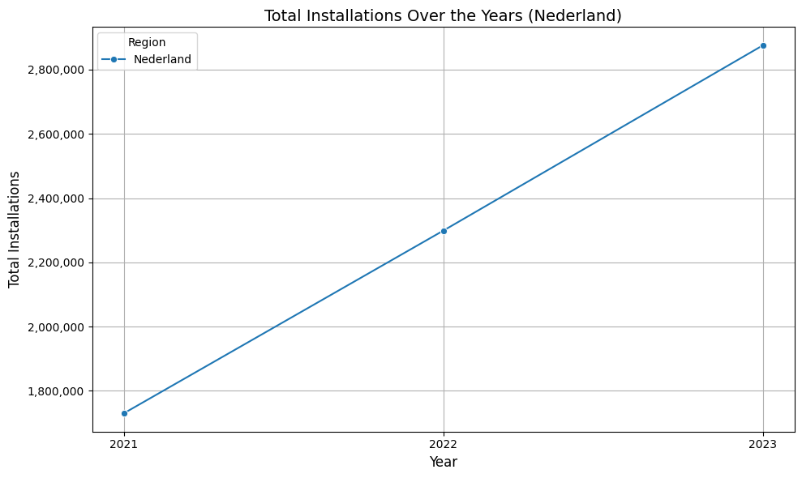

```python
plt.figure(figsize=(10, 6))
sns.lineplot(x=comparison['Year'], y=comparison['Installaties_Nederland'], marker='o', label='Nederland')

plt.title('Total Installations Over the Years (Nederland)', fontsize=14)
plt.xlabel('Year', fontsize=12)
plt.ylabel('Total Installations', fontsize=12)

formatter = plt.FuncFormatter(lambda x, _: f'{int(x):,}')
plt.gca().yaxis.set_major_formatter(formatter)

plt.xticks(ticks=[2021, 2022, 2023])

plt.legend(title='Region', fontsize=10)
plt.grid(True)
plt.tight_layout()
plt.show()
```

The amount of solar panels have increased linearly over the years.

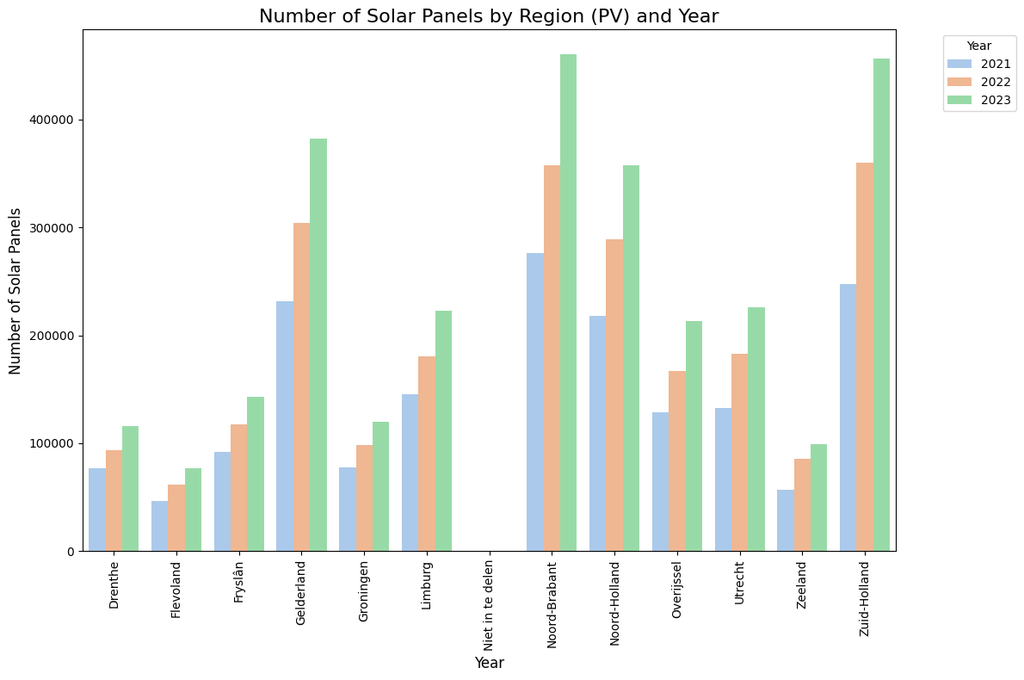

```python
df_filtered = df_regions[df_regions["Regio's"] != 'Nederland']
df_filtered.loc[:, "Regio's"] = df_filtered["Regio's"].str.replace(r'\s*\(PV\)', '', regex=True)

plt.figure(figsize=(12, 8))

sns.barplot(
    data=df_filtered,
    hue="Year",
    y="Installaties",
    x="Regio's",
    palette="pastel"
)

plt.title("Number of Solar Panels by Region (PV) and Year", fontsize=16)
plt.ylabel("Number of Solar Panels", fontsize=12)
plt.xlabel("Year", fontsize=12)
plt.xticks(rotation=90)
plt.legend(title="Year", bbox_to_anchor=(1.05, 1), loc='upper left')

plt.tight_layout()
plt.show()
```

Next we will look at the correlation between the total amount of solar panels in the Netherlands and the solar energy production. For this we will aggregate the solar energy production data to yearly data.

```python
df['year'] = df['date'].dt.year

df_yearly = df.groupby('year', as_index=False).agg({
    'capacity': 'sum',
    'volume': 'sum',
    'percentage': 'mean',
    'emission': 'sum',
    'emissionfactor': 'mean'
})

df_yearly
```

|  | year | capacity | volume | percentage | emission | emissionfactor |
| --- | --- | --- | --- | --- | --- | --- |
| 0 | 2021 | 12296723156 | 12296723156 | 0.130782 | 0 | 0.0 |
| 1 | 2022 | 18386170134 | 18386170134 | 0.147038 | 0 | 0.0 |
| 2 | 2023 | 21796804777 | 21796804777 | 0.136215 | 0 | 0.0 |

We will also add the amount of solar panels to this dataframe.

```python
solar_panels_nederland = df_regions.copy()
solar_panels_nederland = solar_panels_nederland[solar_panels_nederland["Regio's"] == 'Nederland']
solar_panels_nederland.rename(columns={'Year': 'year'}, inplace=True)

df_merged = pd.merge(df_yearly, solar_panels_nederland[['year', 'Installaties']], on='year', how='left', suffixes=('_Yearly', '_Nederland'))
df_merged
```

|  | year | capacity | volume | percentage | emission | emissionfactor | Installaties |
| --- | --- | --- | --- | --- | --- | --- | --- |
| 0 | 2021 | 12296723156 | 12296723156 | 0.130782 | 0 | 0.0 | 1730285.0 |
| 1 | 2022 | 18386170134 | 18386170134 | 0.147038 | 0 | 0.0 | 2298859.0 |
| 2 | 2023 | 21796804777 | 21796804777 | 0.136215 | 0 | 0.0 | 2875487.0 |

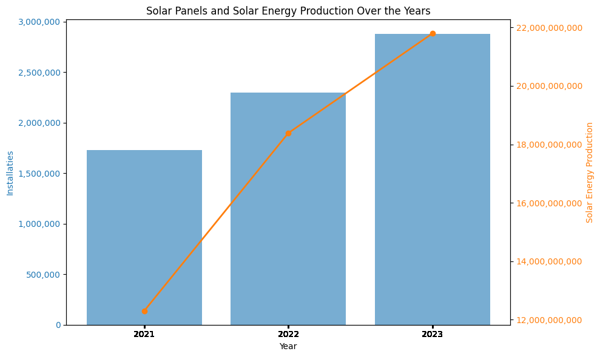

```python
fig, ax1 = plt.subplots(figsize=(10, 6))

ax1.bar(df_merged['year'], df_merged['Installaties'], color='tab:blue', label='Installaties', alpha=0.6)
ax1.set_xlabel('Year')
ax1.set_ylabel('Installaties', color='tab:blue')
ax1.tick_params(axis='y', labelcolor='tab:blue')

ax1.yaxis.set_major_formatter(FuncFormatter(lambda x, _: f'{int(x):,}'))

ax2 = ax1.twinx()
ax2.plot(df_merged['year'], df_merged['capacity'], color='tab:orange', label='Production', marker='o', linewidth=2)
ax2.set_ylabel('Solar Energy Production', color='tab:orange')
ax2.tick_params(axis='y', labelcolor='tab:orange')

ax2.yaxis.set_major_formatter(FuncFormatter(lambda x, _: f'{int(x):,}'))

plt.title('Solar Panels and Solar Energy Production Over the Years')

ax1.set_xticks(df['year'])
ax1.get_xaxis().set_major_formatter(plt.FuncFormatter(lambda x, _: str(int(x))))
plt.xticks(fontsize=12)

fig.tight_layout()
plt.show()
```

```python
growth_installations_2021_2022 = ((2298859 - 1730285) / 1730285) * 100
growth_installations_2022_2023 = ((2875487 - 2298859) / 2298859) * 100

growth_production_2021_2022 = ((18386170134 - 12296723156) / 12296723156) * 100
growth_production_2022_2023 = ((21796804777 - 18386170134) / 18386170134) * 100

print(f"Installations growth 2021 to 2022: {growth_installations_2021_2022:.2f}%")
print(f"Installations growth 2022 to 2023: {growth_installations_2022_2023:.2f}%\n")
print(f"Energy production growth 2021 to 2022: {growth_production_2021_2022:.2f}%")
print(f"Energy production growth 2022 to 2023: {growth_production_2022_2023:.2f}%")
```

```
Installations growth 2021 to 2022: 32.86%
Installations growth 2022 to 2023: 25.08%

Energy production growth 2021 to 2022: 49.52%
Energy production growth 2022 to 2023: 18.55%
```

By looking at the growth in both the amount of solar panels and the solar energy production we can see there has been a significant growth in solar panels between 2022 and 2021. The total amount still increased in 2023, but the growth has slowed down a bit. The growth in solar energy production has increased significantly between 2022 and 2021. This could have different reasons, one of them being the amount of solar panels or even improvements to make the solar panels more efficient in producing energy. The growth in production between 2023 and 2022 has slowed down a lot compared to the previous year. In the graph we saw earlier it we found out that the amount of sunshine per hour and average global radiation was higher in 2022 compared to 2023. This could be one of the reasons why the growth in energy production was lower compared to the previous year.

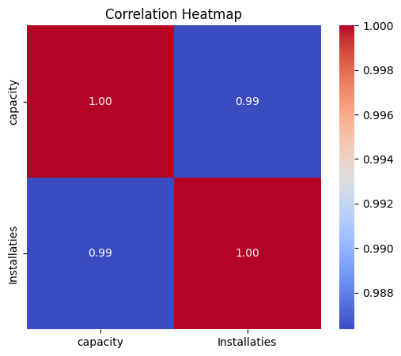

```python
corr = df_merged[['capacity', 'Installaties']].corr()

plt.figure(figsize=(6, 5))
sns.heatmap(corr, annot=True, cmap='coolwarm', fmt='.2f')
plt.title('Correlation Heatmap')
plt.show()
```

There is a really big correlation between the amount of solar panels in the Netherlands and the total solar energy production. This is not very surprising, since the solar energy is produced using the solar panels.

## Conclusion

There are multiple factors that influence the total solar energy production. The biggest factor seems to be the amount of solar panels, which is obvious. Sadly this data is only available per year, so we cannot really use it for making our model. We also found out the weather does have an influence on the solar energy production, so we will use the weather data that is available to make a model.